# Sea Ice Habitats

Data Availability/Quality by Thematic Group Pelagic/Plankton

Nikita Platonov *A.N.Severtsov Institute of Ecology and Evolution* *Russian Academy of Sciences, Moscow

PAMPAN Workshop III Copenhagen, 30 January 2019 (pdf version)

# Sea ice characteristics

- Landfast ice occurrence
- Polynya occurrence
- Distribution of old (multi-year) ice
- Probability of marginal ice zone
- Sea ice edge position

– and technique of processing were proposed during Workshop II in Oslo:

[interactive chart not shown]

# Data preparation

## Processing steps

- Individual Data Layers
- Conservation Features
- Regionalization
- Individual Data Layers (IDL)

  Generalized data set for producing CF
  - Usually time-series of data
  - One IDL is used to produce CF
  - Multiple IDLs are used to produce CF
- Conservation Features (CF)

  Requirements to data for using in MPA planning, *to be*:
  - Persistent
  - Actual
- Regionalization

  Applied to CF only

## Metadata (Individual Data Layers)

| Individual Data Layer | Used for CF? | year | season | Data origin |
| --- | --- | --- | --- | --- |
| Landfast ice occurrence | Yes | 2009 - 2018 | 01 Nov - 31 Jul | Ice charts |
| Polynya occurrence | Yes | 2009 - 2018 | 01 Mar - 31 May | Ice charts |
| Distribution of old (multi-year) ice | Yes | 1979 - 2018 | September | Passive microwave |
| Distribution of old (multi-year) ice | Yes | 2009 - 2018 | 01 Mar - 31 May | Ice charts |
| Distribution of old (multi-year) ice | No | 1989 - 2006 | Mar, Jun, Dec | Belchansky *et al.* (2005) |
| Probability of marginal ice zone | Yes | 1979 - 2017 | 01 Jul - 30 Sep | Passive microwave (Strong and Rigor, 2013) |
| Sea ice edge position and proximity | No | 1979 - 2017 | Monthly | Passive microwave |

## Metadata (Conservation Features)

| Conservation Feature | Season | Regionalization |
| --- | --- | --- |
| Landfast ice occurrence | 01 Nov - 31 Jul | Shore clustering |
| Polynya occurrence | 01 Mar - 31 May | Shore clustering |
| Distribution of old (multi-year) ice | Summer minimum (September) | LME (PAME-led Group, 2013) |
| Distribution of old (multi-year) ice | 01 Mar - 31 May | LME (PAME-led Group, 2013) |
| Probability of marginal ice zone | 01 Jul - 30 Sep | LME (PAME-led Group, 2013) |

## Data Source

- Ice charts

  | IDL, CF | Attribute | Value(s) |
  | --- | --- | --- |
  | Landfast ice occurrence | FA/FB/FC | 08 |
  | Polynya occurrence | SA/SB/SC | 82, 83, 84, 85, 86 |
  | Spring distribution of old (multi-year) ice | SA/SB/SC | 95 |
  | Probability of marginal ice zone (*alternate*) | CT | 18 |

- Passive microwave satellite data: SMMR - SSM/I - SSMIS (since Nov 1978), 25 km grid,  
  not AMSR-E - AMSR2 (since Jul 2002 with gap during Oct 2011 - Jul 2012), 6.25/12.5 km grid

  | IDL, CF |
  | --- |
  | Probability of marginal ice zone |
  | Distribution of old (multi-year) ice in September |
  | Sea ice edge position and proximity |

# Ice charts processing

## AARI spatial coverage

Arctic and Antarctic Research Institute weekly ice chars (AARI, 2018)

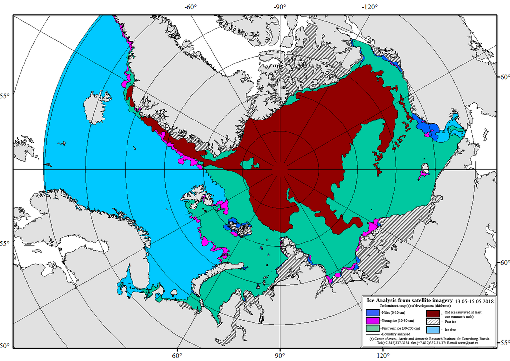

## CIS spatial coverage

Canadian ice service weekly ice charts (CIS, 2009)

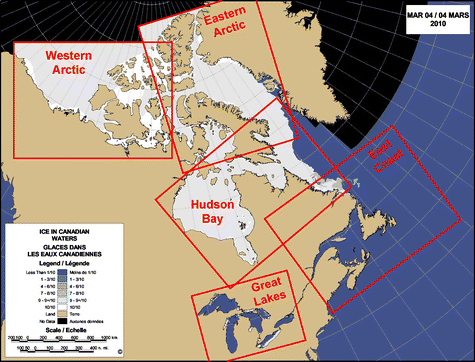

## Spatial join

- Reverse ordered weights for SIGRID-3 FA/FB/FC or SA/SB/SC attributes
- Equal weights for 3 out of 5 CIS “Western Arctic”, “Eastern Arctic” and “Hudson Bay” regions
- Individual weights for joined CIS region and AARI region

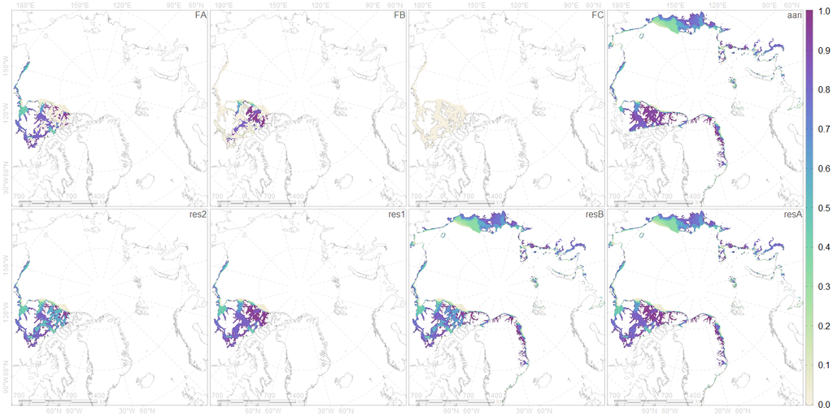

Example for landfast ice for 2016

# Custom regionalization

## Proposed region

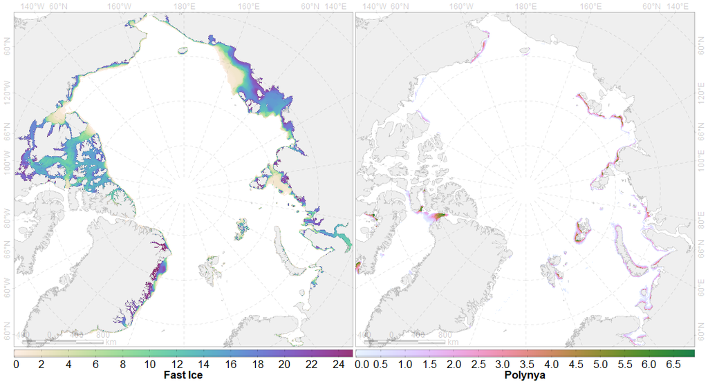

Landfast ice and polynya occurrences

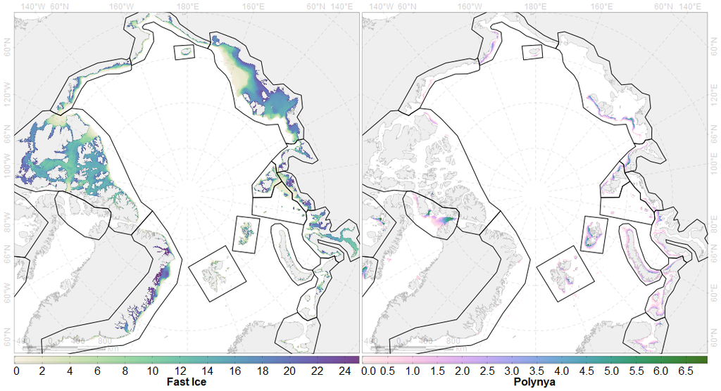

Proposed region over shored ice habitats

## Separate regions

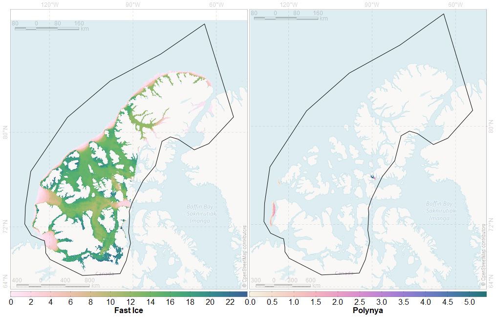

Canadian Archipelago

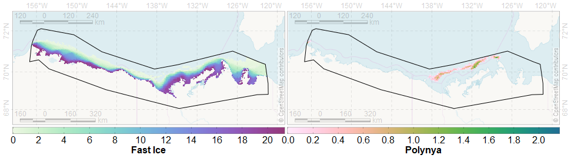

Beaufort Sea

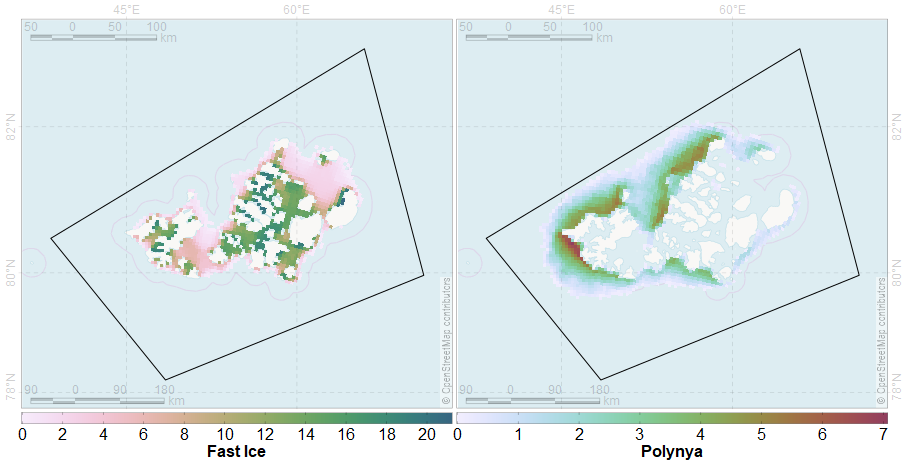

Franz Josef Land

[figure not shown]

Severnaya Zemlya

[figure not shown]

Hudson Bay

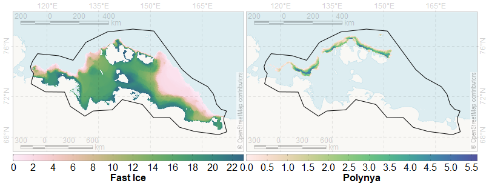

Siberian Shelf

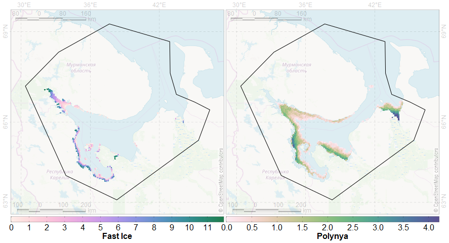

White Sea

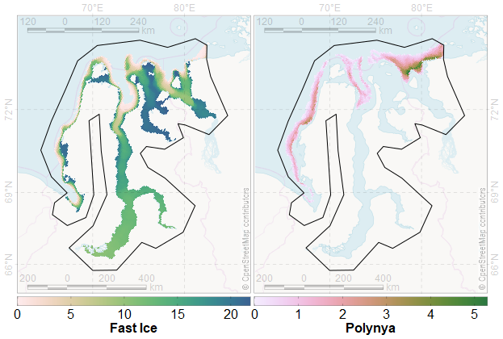

Yamal

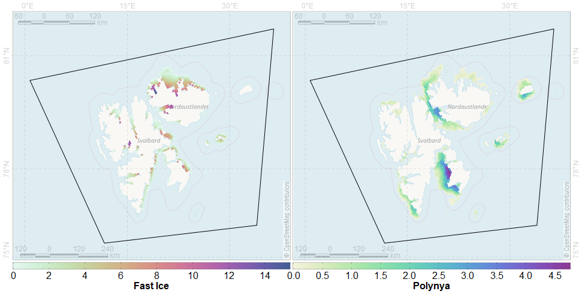

Svalbard

[figure not shown]

Baffin Bay

[figure not shown]

Greenland

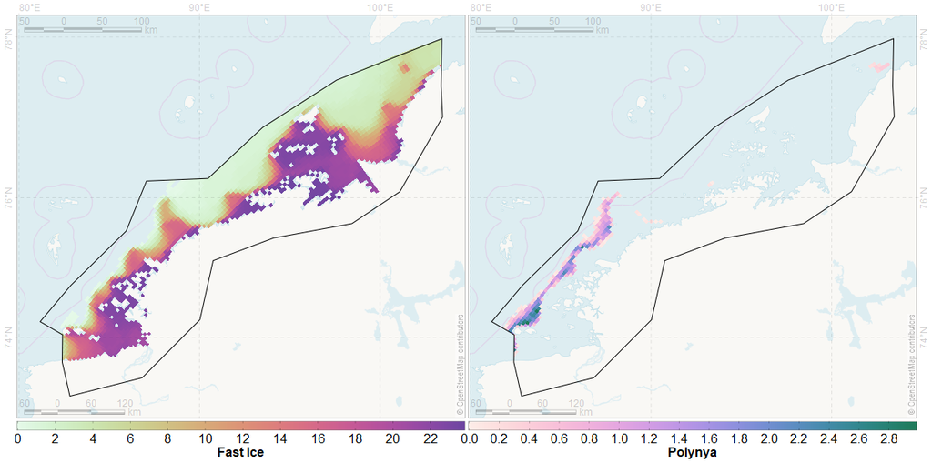

West Taimyr

[figure not shown]

Davis Strait

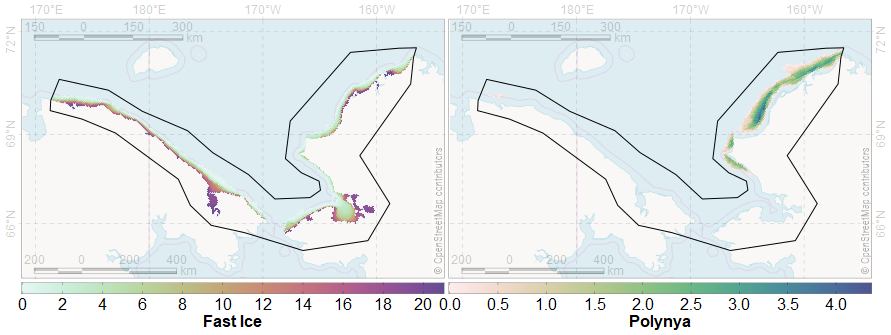

Chukchi Sea

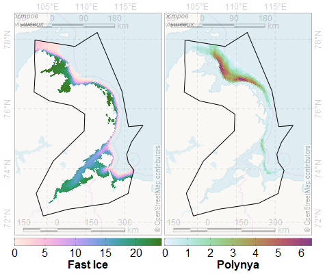

East Taimyr

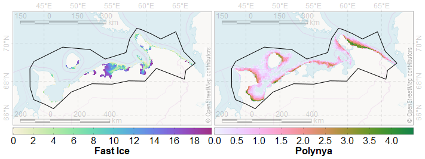

Pechora Sea

[figure not shown]

Kara Sea

[figure not shown]

Wrangel Island

[figure not shown]

Novaya Zemlya

# Obstacles

- Calendar mismatch for communication with thematic group leader
- Lack of oceanographer
- Different WKT standards (OGC, ESRI) for projection specification in QGIS and ArcGIS during “ESRI Shapefile” exchange
- Complicated processing of active microwave data
- Unknown license/copyright/restriction for AARI ice charts data
- Formalized questionnaire for experts to request missed sea ice parameters (IDLs) for their CFs

  | Parameter | Spatial extent | Years | Season | Threshold clarification, *etc* |
  | --- | --- | --- | --- | --- |
  | MIZ |  |  |  |  |

# Thank you

With acknowledgements to WWF for funds and A. N. Severtsov Institute of Ecology and Evolution of Russian Academy of Sciences for appreciation of PAMPAM and other MPA projects.

## References

AARI. 2018. Review ice charts of the Arctic Ocean. Center "Sever", Arctic and Antarctic Research Institute, St. Petersburg. http://www.aari.ru/odata/_d0015.php?lang=1 (accessed 23 November 2018).

Belchansky GI, Douglas DC, Platonov NG. 2005. Spatial and temporal variations in the age structure of arctic sea ice. *Geophysical Research Letters*, 32(18) doi:10.1029/2005GL023976.

CIS. 2009. Canadian Ice Service Arctic Regional Sea Ice Charts in SIGRID-3 Format, Version 1. NSIDC: National Snow and Ice Data Center: Bouder, Colorado USA. doi:10.7265/N51V5BW9.

PAME-led Group. 2013 (15 May). Large Marine Ecosystems LMEs of the Arctic area - Revision LME map 15th of May 2013. Arctic Council’s Protection of the Arctic Marine Environment Working Group (PAME). URI: https://hdl.handle.net/11374/61. https://www.pame.is/index.php/projects/ecosystem-approach/arctic-large-marine-ecosystems-lme-s (accessed 02 December 2018).

Strong C, Rigor IG. 2013. Arctic marginal ice zone trending wider in summer and narrower in winter. *Geophysical Research Letters*, 40(18): 4864–4868. doi:10.1002/grl.50928.